# Préparation CCF E5.2 : Gestion de stock

Ce système sera utilisé dans le cadre de l’épreuve de CCF E5.2.

## Présentation

Il s’agit d’un système de gestion de stock automatisé et communicant qui permet de contrôler et gérer l’utilisation de produits stockés dans des armoires et d’assurer la traçabilité de l’attribution du matériel et des consommables stockés.

Les techniciens interviennent dans des ateliers dans lesquels de nombreux équipements sont utilisés. Ils souhaitent pouvoir disposer d’armoires et d’une gestion de stock afin :

- de rendre accessible le matériel dans un espace sécurisé
- de faciliter un inventaire des stocks avant de passer une commande
- d’assurer un suivi des activités (Qui a effectué l’activité ? Quand ? En combien de temps ?)
- de se libérer de la gestion et du rangement

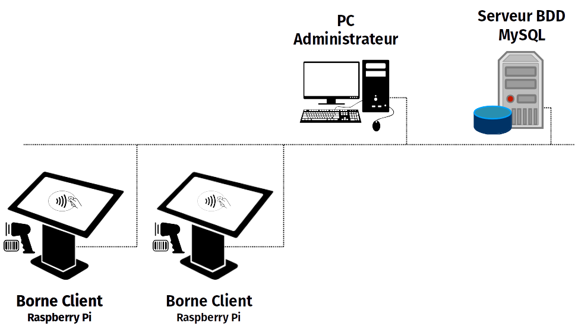

Le serveur BDD héberge un serveur de base de données MySQL.

Chaque borne est équipée :

- d’un lecteur de badge RFID pour contrôler l’accès des utilisateurs
- d’un lecteur de code barre pour identifier les articles stockés
- d’un écran tactile intégré

Une borne est construite autour d’un nano ordinateur Raspberry Pi (processeur ARM) sur lequel est installé le système d’exploitation Raspbian (Linux). Il intègre une application Qt de gestion de stock en mode Kiosque.

Chaque utilisateur devra tout d’abord s’authentifier soit avec un identifiant et un mot de passe soit avec un badge sans contact RFID :

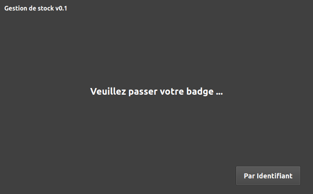

Après authentification, l’utilisateur a la possibilité de consulter le stock des armoires :

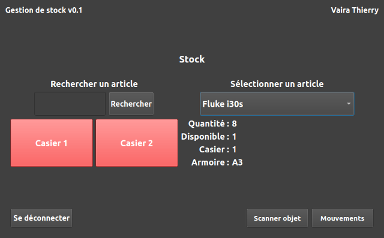

Le diagramme des cas d’utilisation est :

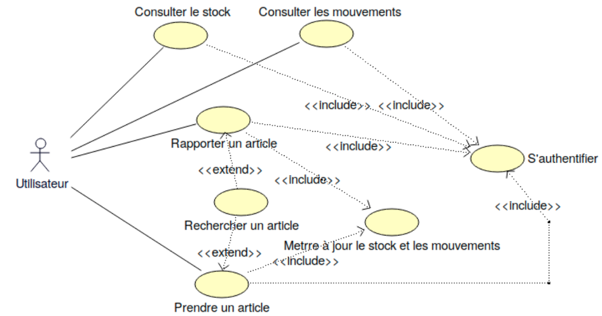

Chaque utilisateur est défini par :

- un nom et un prénom
- un profil : Utilisateur, Gestionnaire ou Administrateur
- un identifiant : l’identifiant que l’utilisateur devra renseigner pour s’authentifier
- un mot de passe : pour s’authentifier
- un badge : le badge RFID pour s’authentifier
- une date de validité : une date limite d’accès pour chaque utilisateur. Passée cette date, l’utilisateur ne pourra plus accéder même avec son badge.
- un groupe : un groupe défini les droits d’accès aux zones de l’armoire. Chaque groupe peut être configuré pour avoir accès à différentes zones. Chaque zone est indépendante. Chaque groupe est indépendant. Un utilisateur n’appartient qu’à un seul groupe à la fois.
- une adresse email : peut être définie pour chaque utilisateur. Les alertes et les stocks seront envoyés si besoin à cette adresse.

Un Utilisateur peut prendre et rendre des articles. Il peut visualiser ses mouvements. Un Gestionnaire peut en plus réapprovisionner le stock, réorganiser le rangement, éditer des articles et gérer les utilisateurs. Un Administrateur possède un accès total et peut donc configurer l’ensemble du système et réaliser une maintenance de premier niveau.

On distinguera deux type d’articles :

- les « consommables » qui sortent définitivement du stock
- les « empruntables » qui peuvent être restitués après leur utilisation

Un article sera caractérisé par : un nom, un code, une désignation puis,

- un type : « Équipement » ou « Consommable »
- un comptage :
  - Aucun : le prélèvement est libre, aucun comptage effectué
  - Automatique : le décompte est fait automatiquement à condition que l’article soit placé sur un emplacement muni d’un système de comptage
  - Code barre : l’article doit être muni d’un code barre et l’opérateur doit, à chaque mouvement, passer le code barre devant le lecteur code barre, pour l’enregistrer et donner la quantité sortie ou entrée.
- un stock : la quantité du stock. Pour les articles qui sont configurés en comptage automatique, la quantité est calculée en fonction du poids unitaire et du poids mesuré sur la balance.
- une unité : l’unité du stock (mètres, pièces, pourcentage, g (grammes), kg (kilogrammes)).

L’administrateur peut réapprovisionner les stocks si besoin, ajouter, modifier ou supprimer les articles, réorganiser le rangement, créer, modifier ou supprimer les comptes des utilisateurs et les groupes.

[figure not shown]

## Contraintes d’environnement

| Ressource | Version |
| --- | --- |
| OS | GNU Linux (Ubuntu 16.04 LTS), Rapsbian |
| API | Qt 5 |

## Manuel d’installation Serveur (PC)

0. Exécuter le programme d’installation setup-estock.sh :

```
$ wget -c http://tvaira.free.fr/bts-sn/activites/preparation-ccf-e52/installateurs/estock/setup-estock.sh
$ sudo ./setup-estock.sh
```

Ce script d’installation assure l’installation de la base de données `e-stock`.

## Manuel d’installation Raspberry Pi/PC

### Borne

Installer l’application pour Raspberry Pi e-stock-rpi.deb :

```
$ wget -c http://tvaira.free.fr/bts-sn/activites/preparation-ccf-e52/installateurs/estock/e-stock-rpi.deb
$ sudo dpkg -i ./e-stock-rpi.deb
```

*Remarque :* L’installation assure aussi la prise en charge du lancement automatique de l’application au démarrage de la Raspberry Pi. Vous pouvez vérifier en réalisant un redémarrage (`sudo reboot`). Si votre système ne démarre pas automatiquement l’interface graphique, il vous faudra le configurer en suivant ce [guide](http://tvaira.free.fr/projets/activites/activite-autostart.html).

Il existe une version pour PC e-stock-pc-1604.deb ou e-stock-pc-1804.deb :

```
$ sudo dpkg -i ./e-stock-pc-xxxx.deb
```

*Remarque :* Pour la version PC, il n’y a évidemment pas de prise en charge du lancement automatique de l’application, ni de mode *kiosk*.

Pour démarrer la version PC, il suffit d’exécuter le programme :

```
$ /usr/local/e-stock/e-stock-pc
```

*Remarque :* Alt-F4 pour fermer l’application.

Pour désinstaller le paquet, il suffit de faire :

```
$ sudo dpkg -P e-stock-rpi

$ sudo dpkg -P e-stock-pc
```

### PC Administrateur

Installer l’application pour PC estock-desktop-1604.deb ou estock-desktop-1804.deb :

```
$ sudo dpkg -i ./e-stock-desktop-xxxx.deb
```

Pour démarrer la version PC, il suffit d’exécuter le programme :

```
$ /usr/local/estock-desktop/e-stock-desktop
```

Pour désinstaller le paquet, il suffit de faire :

```
$ sudo dpkg -P e-stock-desktop
```

## Serveur MySQL

Un pare-feu est installé en configuration `close-config`. L’administration du serveur se fait via **ssh**.

Une tâche *cron* archive les *logs* d’une semaine chaque dimanche à 23h59.

## Configuration

L’application gère ses paramètres de configuration à partir d’un fichier `configuration.ini` :

```
[BDD]
Hostname=192.168.52.12
Password=password
Port=3306
Username=estock
Database=e-stock
```

Le fichier `configuration.ini` est stocké dans le même répertoire que l’application. Il faudra configurer correctement la section **BDD**.

## Glossaire

- Raspberry Pi : nano-ordinateur monocarte à processeur ARM
- Mode kiosque : Le mode kiosque (ou *kiosk*) a été conçu à l’origine pour les bornes internet (*Internet kiosks*) et il est utilisé ici sur un PA. Il met en place un environnement logiciel restreint aux fonctions essentielles : empêcher les utilisateurs d’utiliser le système, dédier l’affichage graphique exclusivement à l’application et enlever les composants graphiques habituels (curseur souris, barre de titre, tableau de bord, icones, etc …).

## Activités

- Matériels : Raspberry Pi, [USB](http://tvaira.free.fr/projets/activites/activite-peripherique-usb.html)
- Réseau : Ethernet, TCP/IP
- Fichiers : LOG, INI et Base de données
- Serveurs : [Serveur Ubuntu](http://tvaira.free.fr/bts-sn/admin/tp-installation-serveur.pdf), [Serveur Base de données](http://tvaira.free.fr/bts-sn/admin/tp-installation-mysql.pdf)
- Autre(s) : [Parefeu](http://tvaira.free.fr/bts-sn/admin/tp-installation-parefeu.pdf), [Utilisateurs](http://tvaira.free.fr/bts-sn/admin/tp-installation-utilisateurs.pdf), [Processus](http://tvaira.free.fr/bts-sn/admin/tp-installation-processus.pdf)

Retour au sommaire